# Frequentist step-by-step implementation

2023-01-02

## Maximum likelihood estimation (MLE): a brief reminder

Suppose we observe a sample of independent observations coming from the same distribution, i.e. $X_i \sim \mathcal{F}$ for $i \in 1\dots N$. Suppose further $\mathcal{F}$ is parametrised by vector $\theta$ governing the distribution, and has the corresponding density $f(\cdot; \theta)$. The likelihood of the observed sample given $\theta$ is then

$$\mathcal{L}_N(\theta; X) = \prod_{i=1}^N f(X_i;\theta)$$

The goal of MLE is to find the optimal vector $\hat{\theta}$, namely

$$\hat{\theta} := {\arg\max}_{\theta \in \Theta}\mathcal{L}_N(\theta; X)$$

where $\Theta$ is called the parameter space. In what follows, we will use this approach to model various risk-related phenomena of increasing complexity, taking us from a simple Weibull distribution to the mixture of experts approach to dealing with competing risks.

### A simple case:

Below we show how to generate a Weibull variable given a vector of parameters, and then use MLE to retrieve this parameters given the data. Type `?rweibull` in the console for more details. For reproducibility, we set the random number seed to `123` using the `set.seed()` function.

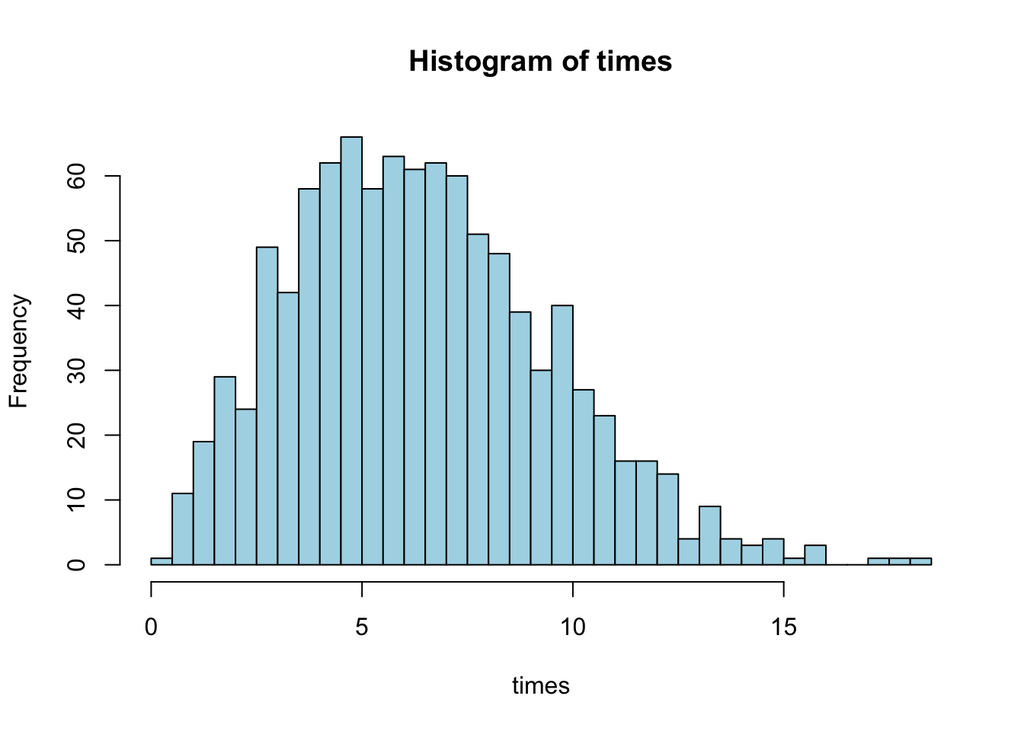

```r
set.seed(123)
n_sim <- 1000
times <- rweibull(n_sim, shape = 2.2, scale = 7.2)
hist(times, breaks = 30, col = "lightblue")
```

Defining the log-likelihood for this simple case – given a vector of parameters $\theta$, which are represented through the `theta` argument of the `ll_weibull()` function below that is a vector of length 2:

- Calculate the Weibull density for each data point with shape/scale set to $(\theta_1,\theta_2)$

- Sum the logs of the densities

```r
ll_weibull <- function(theta, times){
  d  <- dweibull(x=times, shape=theta[1], scale=theta[2])
  ll <- sum(log(d))
  return(ll)
}
```

We now perform maximisation of the `ll_weibull()` function given our data using the `optim()` function, which is the built-in optimisation function of `R`:

- Set the start parameter values for the `theta` vector through the `par` argument
- Define the objective function that is to be optimised using the `fn` argument
- Specify the optimisation method using the `method` argument (if interested, start with `?optim` for an overview of available optimisers)
- Because `optim()` minimises the objective function, we tell the function to multiply the objective by `-1` through the `fnscale` option in the `control` argument, which turns it in a maximisation problem
- Since the `times` argument in the `ll_weibull()` function is not defined by the `optim()` function, we need to specify where the corresponding values can be found, which is the likely-named vector in this case
- After completing the optimisation, the optimal parameters can be extracted from the object that is returned by the `optim()` function

```r
pars <- optim(par=c(1,1), fn=ll_weibull, method="BFGS", control=list(fnscale=-1), times=times)
print(pars$par)
```

```
## [1] 2.217096 7.231121
```

We see that obtained values are not quite the true parameters – this is normal, and becomes less pronounced as sample size increases. You can convince yourself this is the case by playing with `n_sim` in the above.

### With censoring

Unfortunately, very often in real world datasets some of the outcomes are censored because corresponding events fall outside the period of observation. In order to simulate such scenario, we proceed as follows:

- Define an independent exponential variable with a set rate (see `?rexp` for details)
- Tune this parameter, which we defined as `c_rate`, to achieve the level of censoring required
- These times correspond to the *“time left in the experiment”* for each data point

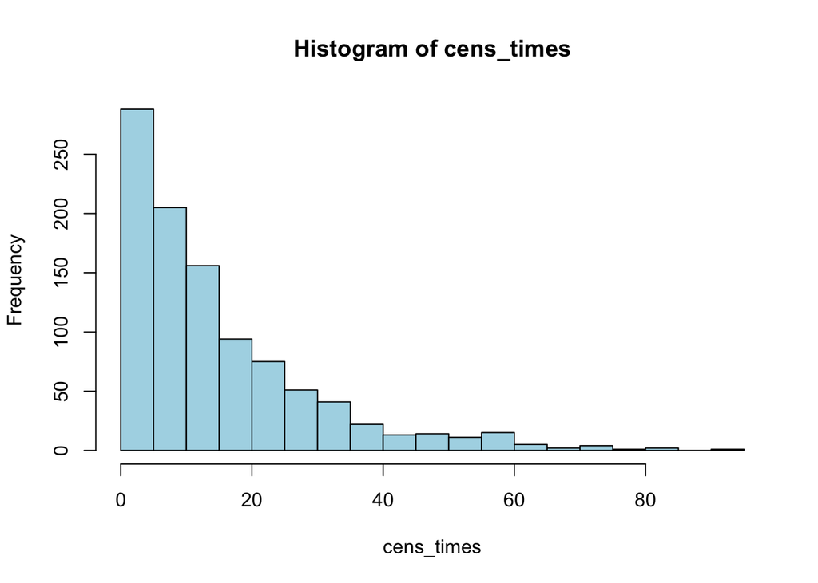

```r
c_rate <- 0.07
cens_times <- rexp(n = n_sim, rate = c_rate)
hist(cens_times, breaks = 25, col = "lightblue")
```

To determine whether an observation will be censored, the ‘censoring times’ are compared with the actual simulated ‘event times’ — each element of the vector `c` below will be:

- 1 if the event time is lower than the censoring time and, hence, the event occurred
- 0 if the censoring time is lower than the even time and, hence, the observation is censored

```r
c <- ifelse(times <= cens_times, 1, 0)
print(paste0("Proportion of censored observations: ", (sum(c==0)/n_sim)*100, "%"))
```

```
## [1] "Proportion of censored observations: 32.5%"
```

Similarly, the actual observed times will be minimum of the event time and the end of the experiment:

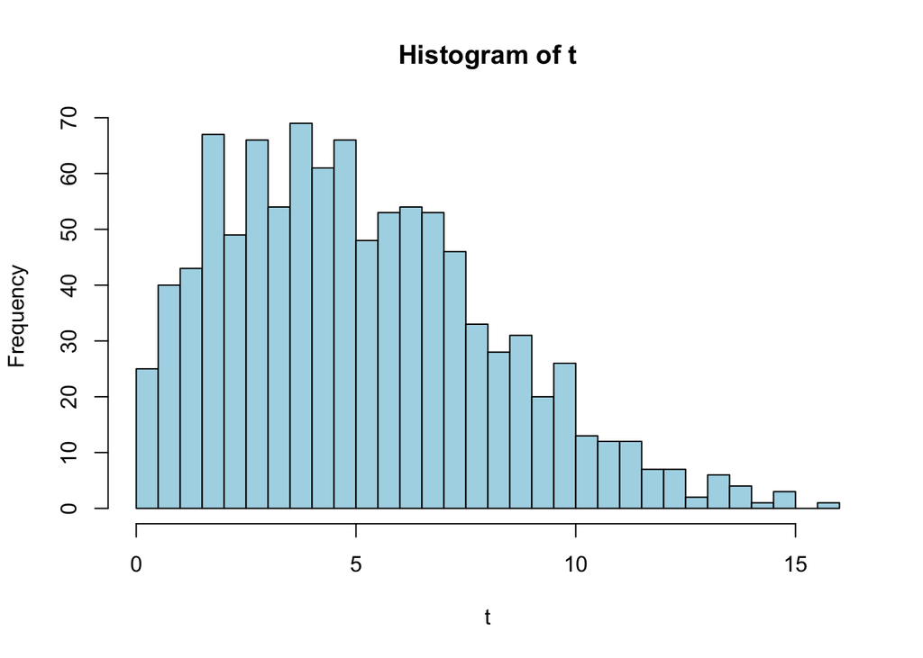

```r
t <- pmin(times, cens_times)
hist(t, breaks = 25, col = "lightblue")
```

The **likelihood** in the presence of censoring is different from the one without censoring

- If an event time $x_i = (t,c)$ is observed (i.e., $c=1$), then $\mathbf{P}(x_i|\theta) = w(t, \theta_k)$, where $w = \frac{d}{dt}\mathcal{W}$ is the density of the Weibull distribution
- If an observation $x_i = (t,c)$ is censored (i.e., $c=0$), then we know that the event has not happened by that time, namely
  $$\mathbf{P}(x_i | \theta) = (1 - \mathcal{W}(t, \theta))$$

The previously defined `ll_weibull()` function can be adapted accordingly to account for the presence of censoring:

- An argument `cens` is added to the function to account for the censoring indicator
- The `ifelse()` function is use to apply the density function if an event occurred (i.e., `cens==1`) or the survival function otherwise (i.e., `cens==0`)

```r
ll_weibull_cens <- function(theta, times, cens){
  l <- ifelse(cens==1,
              dweibull(x=times, shape=theta[1], scale=theta[2]),
              pweibull(q=times, shape=theta[1], scale=theta[2], lower.tail=FALSE))
  ll <- sum(log(l))
  return(ll)
}
```

Now the `optim()` function can be provide in a similar way as before, but with the updated data vectors `t` and `c`, the latter of which is used to define the `cens` argument of the `ll_weibull_cens()` function.

```r
pars_cens <- optim(par=c(1,1), fn=ll_weibull_cens, method="BFGS", control=list(fnscale=-1), times=t, cens=c)
print(pars_cens$par)
```

```
## [1] 2.217436 7.268793
```

### With censoring and covariates

When it comes to real world data, assuming that the distribution of the event times does not depend on the individual is unrealistic. In other words, if we have data on individual-level characteristics, we may want to allow for the possibility that the estimated parameters are informed by such characteristics.

To that end, we incorporate covariates in the model using the following parametrisation:

$$f(y_i|\alpha,\sigma_i) =\frac{\alpha}{\sigma_i}\left(\frac{y_i}{\sigma_i}\right)^{\alpha-1}e^{-(y_i/\sigma_i)^{\alpha}}$$
where

$$\sigma_{i} = \exp{\left( - \frac{\mu + X_{i}^{T}\beta}{\alpha} \right)}$$

is the scale, which now includes participant’s (baseline) information, such as sex, age, etc. We define new functions for sampling from a Weibull distribution based on covariate information (i.e., `rweibull_cov()`), the density function (i.e., `dweibull_cov()`) and the cumulative probability function (i.e., `pweibull_cov()`), according to the above:

```r
rweibull_cov <- function(alpha, mu, beta, x) {
    n <- length(x)
    sig <- exp(-(mu + beta %*% x) / alpha)
    return(rweibull(n = n, shape = alpha, scale = sig))
}

dweibull_cov <- function(t, alpha, mu, beta, x) {
    sig <- exp(-(mu + beta %*% x) / alpha)
    return(dweibull(t, shape = alpha, scale = sig))
}

pweibull_cov <- function(t, alpha, mu, beta, x, lower.tail = TRUE) {
    sig <- exp(-(mu + beta %*% x) / alpha)
    return(pweibull(t, shape = alpha, scale = sig, lower.tail = lower.tail))
}
```

We now generate covariate “age”, normalized at a mean value of zero, set its effect size (`beta_age`), and sample corresponding event times:

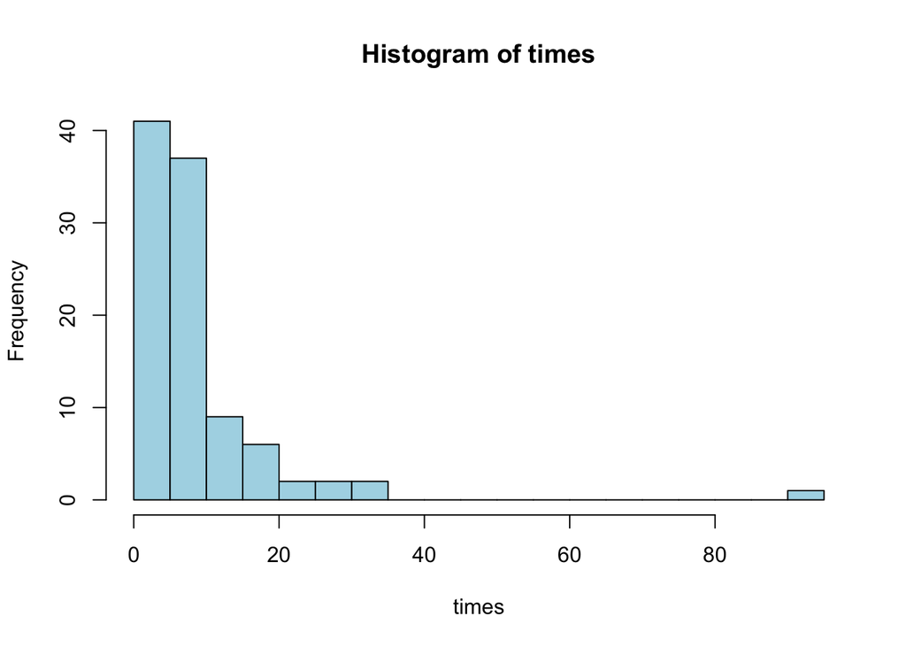

```r
set.seed(123)
n_sim <- 100
age <- rnorm(n = n_sim, mean = 0, sd = 1)

alpha <- 2
mu <- -4
beta_age <- 1.5
times <- rweibull_cov(alpha, mu, beta_age, age)

hist(times, breaks = 30, col = "lightblue")
```

Censoring is performed as before, as well as subsequent steps of defining vectors `t` and `c`:

```r
c_rate <- 0.1
cens_times <- rexp(n = n_sim, rate = c_rate)
c <- ifelse(times <= cens_times, 1, 0)
t <- pmin(times, cens_times)
print(paste0("Proportion of censored observations: ", (sum(c==0)/n_sim)*100, "%"))
```

```
## [1] "Proportion of censored observations: 44%"
```

Of course, we should also adjust the code for the likelihood accordingly — it looks similar to the `ll_weibull_cens_cov()` function, but now the density and probability functions include the covariates vector `X` and the custom functions that accommodate for the the covariates:

```r
ll_weibull_cens_cov <- function(theta, times, cens, X){
  l <- ifelse(cens==1,
              dweibull_cov(t=times, alpha=theta[1], mu=theta[2], beta=theta[3], x=X),
              pweibull_cov(t=times, alpha=theta[1], mu=theta[2], beta=theta[3], x=X, lower.tail=FALSE))
  ll <- sum(log(l))
  return(ll)
}
```

Similarly, the call of the `optim()` functions needs to be updated to provide a start value for an additional parameter and to provide the `age` vector as value for argument `X`:

```r
pars_cens_cov <- optim(par=c(1,0,0), fn=ll_weibull_cens_cov, method="BFGS", control=list(fnscale=-1), times=t, cens=c, X=age)
print(pars_cens_cov$par)
```

```
## [1]  1.924314 -4.032279  1.556175
```

### One risk is good – two risks are more realistic

We are now very close — one thing we need to learn how to do is dealing with multiple competing risks. In line with the definition of the event-specific probabilities and distributions (ESPD) modelling approach (see paper for details), we do the following:

1. Pick which event will happen according to mixture proportions
2. Sample time to event given parameters of the chosen risk

This is illustrated in the code below:

- Two sets of parameters are now defined, i.e. `theta1` and `theta2`, one for each competing event
- The probability that competing event 1 occurs, i.e. `prob1` is defined to be 30%
- For illustration purposes, covariates are ignored for now

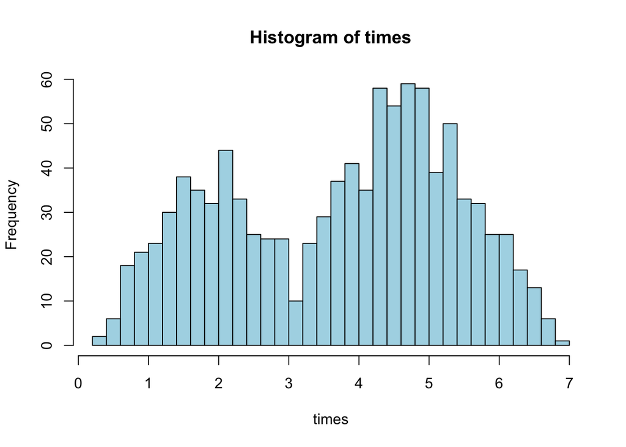

```r
set.seed(123)
n_sim <- 1000
theta1 <- c(3, 2)
theta2 <- c(5, 5)
prob1 <- c(0.3)

times1 <- rweibull(n_sim, shape = theta1[1], scale = theta1[2])
times2 <- rweibull(n_sim, shape = theta2[1], scale = theta2[2])

events <- sample(x = c(1,2), size = n_sim, prob = c(prob1, 1-prob1), replace = TRUE)
times <- ifelse(events==1, times1, times2)

hist(times, breaks = 30, col = "lightblue")
```

Notice above that, as expected, the distribution is bi-modal (two risks considered)! Next, censoring is applied as before, with the exception that there are now two types of events that can occur in addition to censoring. Hence, we rename the censoring vector `c` to event vector `e`, with values: 0 for censoring, 1 for event 1, and 2 for event 2:

```r
c_rate <- 0.1
cens_times <- rexp(n = n_sim, rate = c_rate)
e <- ifelse(times <= cens_times, events, 0)
t <- pmin(times, cens_times)
print(paste0("Proportion of censored observations: ", (sum(e==0)/n_sim)*100, "%"))
```

```
## [1] "Proportion of censored observations: 31.5%"
```

In defining the likelihood function for the mixture, the vector of mixture proportions or event probabilities, $\pi$, describes a probability distribution. In other words, all its elements are non-negative and sum to one. This makes what follows a constrained optimisation problem. In order to avoid dealing with resulting complications, we use a *sigmoid* function to transform the probabilities to log-odds ratios, like in logistic regression modelling:

```r
sigmoid <- function(x){
  return(1/(1+exp(-x)))
}
```

A similar procedure is often applied to parameters of the distributions like the Weibull distribution in this example. By modelling the shape and scale parameter on log-scale, it can be assured their values are non-negative according to their definition. This is also implemented in the general function that will be introduced later for modelling competing events according to the ESPD approach.

Based on the above, the likelihood is defined below. The `theta` vector now contains 5 parameters: 1 for the probability of event 1, 2 for the Weibull distribution for event 1, and 2 for the Weibull distribution for event 2. Note that there are now two events in addition to the censoring status. Rather than using nested if-else statements, the code below illustrates how to us a power-calculation to set the values to 1 if the event did not occur, or to their respective value if th event did occur. For example, the term `(events==1)` results in a vector of ones for those who experienced event 1, and zeros for those for whom the event was not 1. The result is that for those who experiences event 1, the density applies, whereas for the others a value of 1 will be returned, i.e. they are not considered in the likelihood for event 1.

```r
ll_weibull_mix <- function(theta, times, events){
  p1 <- sigmoid(theta[1])
  l1 <- (p1*dweibull(times, theta[2], theta[3]))^(events==1)
  l2 <- ((1-p1)*dweibull(times, theta[4], theta[5]))^(events==2)
  l0 <- (p1*pweibull(times, theta[2], theta[3], FALSE) + (1-p1)*pweibull(times, theta[4], theta[5], FALSE))^(events==0)
  ll <- sum(log(l1) + log(l2) + log(l0))
  return(ll)
}
```

After defining the likelihood function, the call of the `optim()` functions needs to be updated to provide start values for all 5 parameters, and to provide the `events` argument:

```r
pars_mix_cens <- optim(par=c(0,1,1,1,1), fn=ll_weibull_mix, method="BFGS", control=list(fnscale=-1), times=t, events=e)

print(sigmoid(pars_mix_cens$par[1]))
```

```
## [1] 0.3104839
```

```r
print(pars_mix_cens$par[-1])
```

```
## [1] 2.949100 1.925460 5.370132 5.062812
```

### Applying it to the case study

We are now in a position to put everything we have learned so far to practical use. We proceed as follows (also see the manuscript for an introduction to the case study and further context):

- Load the `melanoma` dataset from the `boot` package and wrangle it to correspond to the required format
- Define covariates for both death and progression risk processes, as well as mixture proportions
- Define the `ll_weibull_mix_cov` in order to find the optimal parameter values by maximum likelihood

First, we load the `melanoma` dataset from the `boot` package and define the competing events:

```r
# Loading the melanoma dataset
mel_df <- boot::melanoma

# Transforming time from days to years
times <- mel_df$time / 365.25

# Defining the event indicator based on the status variable in the datases:
# - status = 1 corresponds to death
# - status = 2 corresponds to recurrence
# - status = 3 corresponds to censoring
events <- ifelse(mel_df$status==1, 'death', ifelse(mel_df$status==2, 'recur', 'cens'))
```

Next, we define the covariate matrix `X` including the age, sex, ulceration status, and tumor thickness for each individual (note that we scale the age and thickness variables using the `scale()` function that is part of the standard installation of `R`):

```r
# Construct the matrix of covariates, adding the incercept column filled with 1's
X <- cbind(1, scale(mel_df$age), mel_df$sex, mel_df$ulcer, scale(mel_df$thickness))

# Set the column names accordingly
colnames(X) <- c('intercept', 'age', 'sex', 'ulcer', 'thickness')
```

Combining all the above, we can define a custom log-likelihood function for this case study as introduced and explained in the manuscript:

```r
ll_weibull_mix_cov <- function(coefs, times, events, X){

  # Extract the coefficients for the different parameters from the vector
  coefs_logit_recur <- coefs[1:5]
  coefs_shape_recur <- coefs[6]
  coefs_scale_recur <- coefs[7:11]
  coefs_shape_death <- coefs[12]
  coefs_scale_death <- coefs[13:17]

  # Obtain the patient-level parameters based on the patient covariates
  # and the extracted parameter coefficients
  p_recur     <- sigmoid(coefs_logit_recur)
  shape_recur <- exp(coefs_shape_recur)
  scale_recur <- exp(X %*% coefs_scale_recur)
  shape_death <- exp(coefs_shape_death)
  scale_death <- exp(X %*% coefs_scale_death)

  # Log likelihood for those who recurred
  ll_recur <- p_recur * dweibull(times, shape_recur, scale_recur)^(events == 'recur')

  # Log likelihood for those who deceased
  ll_death <- (1-p_recur) * dweibull(times, shape_death, scale_death)^(events == 'death')

  # Log likelihood for censored event
  ll_cens <- (p_recur * pweibull(times, shape_recur, scale_recur, FALSE) +
                  (1-p_recur) * pweibull(times, shape_death, scale_death, FALSE))^(events == 'cens')

  # Combine the log likelihoods
  ll <- sum(log(ll_recur) + log(ll_death) + log(ll_cens))

  return(ll)

}
```

We can now perform the optimization using the `optim()` function. Additionally, the code below demonstrates how it can be performed using the `maxLik()` function from the `maxLim` package, which was developed for this exact purpose and has some benefits like returning the variance-covariance matrix, as discussed in the manuscript. Different than for previous illustrations above, we first define the start values for the parameters and give them names, so that the results can be interpreted more easily:

```r
# Define the start values for the coefficients and name them
start_values <- setNames(
  object = rep(x = 0, times = 17),
  nm = c('logit_recur_intercept', 'logit_recur_age', 'logit_recur_ sex',
       'logit_recur_ ulceration', 'logit_recur_thickness', 'logshape_recur',
       'logscale_recur_intercept', 'logscale_recur_age',
       'logscale_recur_ sex', 'logscale _recur_ ulceration',
       'logscale_recur_thickness', 'logshape_death',
       'logscale_death_intercept', 'logscale_death_age',
       'logscale_death_ sex', 'logscale_death_ ulceration',
       'logscale_death_thickness')
)

# Perform the likelihood optimization using the optim() function
pars_optim <- optim(par=start_values, fn=ll_weibull_mix_cov, method="BFGS", control=list(fnscale=-1), times=times, events=events, X=X)

# Perform the likelihood optimization using the maxLik() function
pars_maxLik <- maxLik(
  logLik = ll_weibull_mix_cov,
  start = start_values,
  times = times,
  events = events,
  X = X
)

# Extract and compare the coefficients
cbind(optim = pars_optim$par, maxLik = coef(pars_maxLik))
```

```
##                                     optim        maxLik
## logit_recur_intercept        0.0064381205  0.0063285521
## logit_recur_age              0.0342965403  0.0342916777
## logit_recur_ sex             0.0008295461  0.0007701758
## logit_recur_ ulceration      0.0285469663  0.0285053595
## logit_recur_thickness        0.0184201672  0.0183085128
## logshape_recur               1.1507635269  1.1507438784
## logscale_recur_intercept     2.0912219030  2.0912287558
## logscale_recur_age          -0.1292652876 -0.1292517051
## logscale_recur_ sex          0.0221339403  0.0221231053
## logscale _recur_ ulceration -0.0711439802 -0.0711448498
## logscale_recur_thickness     0.0673242737  0.0673650329
## logshape_death               0.6437149221  0.6437031991
## logscale_death_intercept     1.8193118524  1.8193655204
## logscale_death_age           0.0046415806  0.0046047085
## logscale_death_ sex         -0.3338170156 -0.3340507425
## logscale_death_ ulceration  -0.3234115082 -0.3234220153
## logscale_death_thickness    -0.1652978061 -0.1652842528
```

As you can see and as expected, the estimates of the parameters are very similar regardless of the optimisation function used. The estimated parameters can now be used in a discrete event simulation to model the competing events of recurrence and death.

### What next?

In this tutorial we showed how to perform maximum likelihood estimation for the case of competing risks from scratch. However, this is not the end of the road – in reality one may require quite a bit more flexibility, such as allowing for different parametric families of distributions for individual risks, as well goodness-of-fit diagnostics such as information criteria.

Having mastered material in this notebook, you are well-positioned to develop all that functionality yourself, but thankfully we have already done it so that you don’t have to!

The `ESPD_frequentist.R` script contains a general function that has all the functionality you may ever require, and used the `maxLik` package for the maximum likelihood estimation so that the variance-covariance matrix is obtained as well. The above material should be sufficient for anyone to get a good grasp of what is happening under the hood of this function through the extensive comments that it includes. We look forward to you trying it out and letting us know what you think!